# STA5076Z Assignment 2: SONA Predict the President

We have run 60 previous versions of this model to help determine what the best parameter setting should be. There were 20 tests, where each test was run 3 times and the best test accuracy was recorded. It is difficult to exactly repreduce the keras results from within R as Phyton will set its own random values with a different seed. The following table provide a summary of these tests. Note that parameter values are only displayed when a change to it was made. If no value is displayed in one of the parameter columns then the previous value was used for that specific test.

```r
cnn_parameter_tests = read.csv("cnn_parameter_tests.csv")
cnn_parameter_tests$Test.Accuracy = round(cnn_parameter_tests$Test.Accuracy,4) * 100
data.frame(cnn_parameter_tests)
```

| Test | max_features | minlen | maxlen | embedding_dims | batch_size | filters | Test.Accuracy |
| --- | --- | --- | --- | --- | --- | --- | --- |
| 1 | 9450 | 1 | 30 | 20 | 32 | 250 | 58.97 |
| 2 | NA | NA | NA | NA | 16 | NA | 59.67 |
| 3 | NA | NA | NA | NA | 64 | NA | 57.85 |
| 4 | 2000 | NA | NA | NA | NA | NA | 61.04 |
| 5 | 3000 | NA | NA | NA | NA | NA | 59.56 |
| 6 | 4000 | NA | NA | NA | NA | NA | 56.88 |
| 7 | 6000 | NA | NA | NA | NA | NA | 57.50 |
| 8 | 3000 | NA | NA | NA | 16 | NA | 58.85 |
| 9 | NA | 2 | NA | NA | NA | NA | 59.88 |
| 10 | NA | 3 | NA | NA | NA | NA | 59.37 |

[output cut: 10 more lines]

We can again try and see if we can improve on this model by correcting the class imbalances. The previous class weights calculated on the sona_sentences object which was use for the sona_matrix cannot be used in this case as we have how excluded short sentences. The following table display the new weights which we should consider for our CNN model:

```r
cnn_class_balance = read.csv("cnn_class_balance.csv")
data.frame(cnn_class_balance)
```

| id | president | sentence.count | sentence.percentage | Class.Balance.. | Correct.sampling.using.the.Class.Balance.. | Number.of.additional.samples.needed |
| --- | --- | --- | --- | --- | --- | --- |
| 0 | deKlerk | 89 | 1.32 | 26.8 | 2383 | 2294 |
| 1 | Mandela | 1547 | 22.63 | 1.5 | 2383 | 836 |
| 2 | Mbeki | 2288 | 33.10 | 1.0 | 2383 | 95 |
| 3 | Motlanthe | 248 | 3.60 | 9.6 | 2383 | 2135 |
| 4 | Zuma | 2383 | 36.12 | 1.0 | 2383 | 0 |
| 5 | Ramaphosa | 223 | 3.23 | 10.7 | 2383 | 2160 |

We can try 3 different approaches:

1. Use the class_weight attribute when fitting the keras model, and set the weights according to how additional sampling should take place. E.g. Zuma (ID=4) have the most sentences and do not require any correction, therefor class weight is 1. deKlerk (ID=0) on the other hand has the least number of sentences and require the biggest correction, which is a class weight of 26.8. The “Class.Balance”" attribute above list these weights.
2. Also use the keras class_weight attribute, but in this case set the class weights to the partial percentage which the class is contributing to. E.g. for Zuma 36.1% and for deKlerk 1.3%. The “sentence.percentage”" attribute above list these weights. Note that this approach is less common than the first, but still referred to in literature.
3. Correcting the class imbalances by adding extra samples for the classes which require adjustments. E.g. for Zuma 0 additional samples will be needed, but for deKlerk we will need to add an extra 2294 samples. The “Number.of.additional.samples.needed” attribute above list these extra number of samples required.

Approach 1:

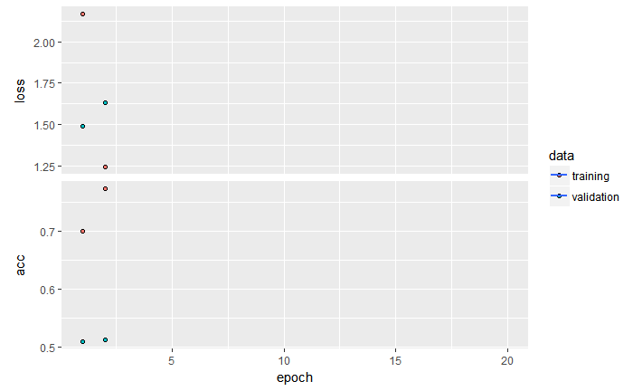

```r
# fit model
history4.1 = model4 %>%
  fit(x = x_train_cnn,
      y = y_train_cnn,
      class_weight = list("0"=26.8, "1"=1.5, "2"=1.0, "3"=9.6, "4"=1.0, "5"=10.7),
      epochs = 20,
      batch_size = 16,
      callbacks = list(callback_early_stopping(monitor = "val_loss", min_delta = 0.001, patience = 1)),
      verbose = 0,
      validation_data = list(x_test_cnn, y_test_cnn))
plot(history4.1)
```

```r
cat("Train classification success rate = ", mean(model4$predict_classes(x_train_cnn) == train_cnn$y), "\n")
```

```
Train classification success rate =  0.8935817
```

```r
cat("Test classification success rate = ", mean(model4$predict_classes(x_test_cnn) == test_cnn$y))
```

```
Test classification success rate =  0.5125369
```

```r
pres_predicted4.1 = c("deKlerk", "Mandela", "Mbeki", "Motlanthe", "Zuma", "Ramaphosa")[ match(model4$predict_classes(x_test_cnn), (0:5))]
pres_actual_cnn = c("deKlerk", "Mandela", "Mbeki", "Motlanthe", "Zuma", "Ramaphosa")[ match(test_cnn$y, (0:5))]
kable(table(predicted = pres_predicted4.1, actual = pres_actual_cnn),
      caption = "Training confusion matrix for CNN (Approach 1)",
      row.names = TRUE, digits = 0)
```

|  | deKlerk | Mandela | Mbeki | Motlanthe | Ramaphosa | Zuma |
| --- | --- | --- | --- | --- | --- | --- |
| deKlerk | 9 | 9 | 8 | 0 | 2 | 6 |
| Mandela | 4 | 148 | 102 | 9 | 9 | 49 |
| Mbeki | 1 | 83 | 225 | 21 | 11 | 57 |
| Motlanthe | 2 | 16 | 41 | 9 | 2 | 21 |
| Ramaphosa | 1 | 17 | 25 | 4 | 7 | 55 |
| Zuma | 0 | 32 | 51 | 9 | 14 | 297 |

```r
# Prediction accuracy per president
pres_predicted4.1 = data.frame(round(diag(table(predicted = pres_predicted4.1, actual = pres_actual_cnn)) / table(pres_actual_cnn), 4) * 100)
colnames(pres_predicted4.1) = c("President", "Accuracy")
pres_predicted4.1
```

| President | Accuracy |
| --- | --- |
| deKlerk | 52.94 |
| Mandela | 48.52 |
| Mbeki | 49.78 |
| Motlanthe | 17.31 |
| Ramaphosa | 15.56 |
| Zuma | 61.24 |

Approach 2:

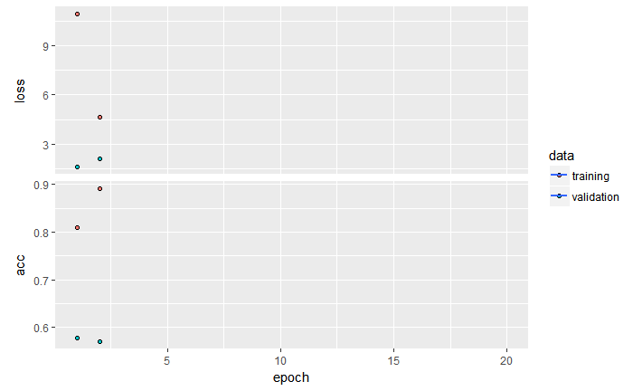

```r
# fit model
history4.2 = model4 %>%
  fit(x = x_train_cnn,
      y = y_train_cnn,
      class_weight = list("0"=1.3, "1"=22.6, "2"=33.1, "3"=3.6, "4"=36.1, "5"=3.2),
      epochs = 20,
      batch_size = 16,
      callbacks = list(callback_early_stopping(monitor = "val_loss", min_delta = 0.001, patience = 1)),
      verbose = 0,
      validation_data = list(x_test_cnn, y_test_cnn))
plot(history4.2)
```

```r
cat("Train classification success rate = ", mean(model4$predict_classes(x_train_cnn) == train_cnn$y), "\n")
```

```
Train classification success rate =  0.9496496
```

```r
cat("Test classification success rate = ", mean(model4$predict_classes(x_test_cnn) == test_cnn$y))
```

```
Test classification success rate =  0.5707965
```

```r
pres_predicted4.2 = c("deKlerk", "Mandela", "Mbeki", "Motlanthe", "Zuma", "Ramaphosa")[ match(model4$predict_classes(x_test_cnn), (0:5))]
kable(table(predicted = pres_predicted4.2, actual = pres_actual_cnn),
      caption = "Training confusion matrix for CNN (Approach 2)",
      row.names = TRUE, digits = 0)
```

|  | deKlerk | Mandela | Mbeki | Motlanthe | Ramaphosa | Zuma |
| --- | --- | --- | --- | --- | --- | --- |
| deKlerk | 5 | 1 | 1 | 0 | 0 | 0 |
| Mandela | 4 | 140 | 97 | 11 | 8 | 42 |
| Mbeki | 5 | 105 | 265 | 28 | 15 | 78 |
| Motlanthe | 0 | 1 | 1 | 0 | 0 | 2 |
| Ramaphosa | 2 | 1 | 2 | 0 | 3 | 2 |
| Zuma | 1 | 57 | 86 | 13 | 19 | 361 |

```r
# Prediction accuracy per president
pres_predicted4.2 = data.frame(round(diag(table(predicted = pres_predicted4.2, actual = pres_actual_cnn)) / table(pres_actual_cnn), 4) * 100)
colnames(pres_predicted4.2) = c("President", "Accuracy")
pres_predicted4.2
```

| President | Accuracy |
| --- | --- |
| deKlerk | 29.41 |
| Mandela | 45.90 |
| Mbeki | 58.63 |
| Motlanthe | 0.00 |
| Ramaphosa | 6.67 |
| Zuma | 74.43 |

Approach 3:

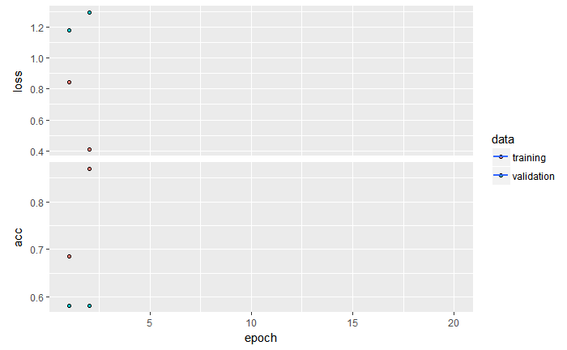

```r
# build train and test set
train_cnn = list()
test_cnn = list()
train.index.main = train.index.cnn # save the original training indexes
# add indexes for correction of class imbalance
# add extra 2294 samples for deKlerk to correct class imbalances
train.index.cnn = c(train.index.main,
                    sample(which(predicter_presidents_name_cnn[train.index.main] == "deKlerk"),
                           size = 2294,
                           replace = T))
# add extra 836 samples for Mandela to correct class imbalances
train.index.cnn = c(train.index.cnn,
                    sample(which(predicter_presidents_name_cnn[train.index.main] == "Mandela"),
                           size = 836,
                           replace = T))
# add extra 95 samples for Mbeki to correct class imbalances
train.index.cnn = c(train.index.cnn,
                    sample(which(predicter_presidents_name_cnn[train.index.main] == "Mbeki"),
                           size = 95,
                           replace = T))
# add extra 2135 samples for Motlanthe to correct class imbalances
train.index.cnn = c(train.index.cnn,
                    sample(which(predicter_presidents_name_cnn[train.index.main] == "Motlanthe"),
                           size = 2135,
                           replace = T))
# add extra 2160 samples for Ramaphosa to correct class imbalances
train.index.cnn = c(train.index.cnn,
                    sample(which(predicter_presidents_name_cnn[train.index.main] == "Ramaphosa"),
                           size = 2160,
                           replace = T))
# follow usual steps from here
train_cnn$x = sequences[train.index.cnn]
test_cnn$x =  sequences[-train.index.cnn]
train_cnn$y = predicter_presidents_id_cnn[train.index.cnn]
test_cnn$y =  predicter_presidents_id_cnn[-train.index.cnn]
# padd shorter sequences with zeros
x_train_cnn = train_cnn$x %>% pad_sequences(maxlen = maxlen)
x_test_cnn = test_cnn$x %>% pad_sequences(maxlen = maxlen)
# one hot encoding
y_train_cnn = to_categorical(train_cnn$y)
y_test_cnn = to_categorical(test_cnn$y)
# initiate model
model4.3 = keras_model_sequential()
# define model layers
model4.3 %>%
  # embedding layer maps vocab indices into embedding_dims dimensions
  layer_embedding(max_features, embedding_dims, input_length = maxlen) %>%

  # add some dropout
  layer_dropout(0.2) %>%

  # convolutional layer
  layer_conv_1d(
    filters = 500,
    kernel_size = 3,
    padding = 'valid',  # "valid" means no padding, as we did it already
    activation = 'relu',
    strides = 1) %>%
  layer_global_max_pooling_1d() %>%

  layer_dense(units = 128,
              activation = 'relu') %>%
  layer_dropout(0.2) %>%
  layer_dense(units = output_shape) %>%
  layer_activation('softmax')
# compile model
model4.3 %>% compile(
  optimizer = 'adam',
  loss = 'categorical_crossentropy',
  metrics = c('accuracy')
)
# fit model
history4.3 = model4.3 %>%
  fit(x = x_train_cnn,
      y = y_train_cnn,
      epochs = 20,
      batch_size = 16,
      callbacks = list(callback_early_stopping(monitor = "val_loss", min_delta = 0.001, patience = 1)),
      verbose = 0,
      validation_data = list(x_test_cnn, y_test_cnn))
plot(history4.3)
```

Save model

```r
save_model_hdf5(model4.3, "models/Waldo_SONA_model4.3.h5") #save model to use later on
save_model_weights_hdf5(model4.3, "models/Waldo_SONA_model4.3_weights.h5") #save model weights to use later on
save(history4.1, file = "models/history4.1.RData")
save(history4.2, file = "models/history4.2.RData")
save(history4.3, file = "models/history4.3.RData")
```

Load model

```r
#model4.3 = load_model_hdf5("models/Waldo_SONA_model4.3.h5")
#load_model_weights_hdf5(model4.3, "models/Waldo_SONA_model4.3_weights.h5")
#load("models/history4.1.RData")
#load("models/history4.2.RData")
#load("models/history4.3.RData")
```

```r
cat("Train classification success rate = ", mean(model4.3$predict_classes(x_train_cnn) == train_cnn$y), "\n")
```

```
Train classification success rate =  0.9343996
```

```r
cat("Test classification success rate = ", mean(model4.3$predict_classes(x_test_cnn) == test_cnn$y))
```

```
Test classification success rate =  0.5814978
```

```r
pres_actual4.3 = c("deKlerk", "Mandela", "Mbeki", "Motlanthe", "Zuma", "Ramaphosa")[ match(test_cnn$y, (0:5))]
pres_predicted4.3 = c("deKlerk", "Mandela", "Mbeki", "Motlanthe", "Zuma", "Ramaphosa")[ match(model4.3$predict_classes(x_test_cnn), (0:5))]
kable(table(predicted = pres_predicted4.3, actual = pres_actual4.3),
      caption = "Training confusion matrix for CNN (Approach 3)",
      row.names = TRUE, digits = 0)
```

|  | deKlerk | Mandela | Mbeki | Motlanthe | Ramaphosa | Zuma |
| --- | --- | --- | --- | --- | --- | --- |
| deKlerk | 2 | 0 | 1 | 0 | 1 | 1 |
| Mandela | 4 | 145 | 95 | 10 | 12 | 51 |
| Mbeki | 4 | 56 | 173 | 17 | 9 | 47 |
| Motlanthe | 0 | 6 | 2 | 5 | 3 | 7 |
| Zuma | 2 | 39 | 76 | 12 | 20 | 335 |

```r
# Prediction accuracy per president
pres_predicted4.3 = data.frame(round(diag(table(predicted = pres_predicted4.3, actual = pres_actual4.3)) / table(pres_actual4.3), 4) * 100)
```

```
longer object length is not a multiple of shorter object length
```

```r
colnames(pres_predicted4.3) = c("President", "Accuracy")
pres_predicted4.3
```

| President | Accuracy |
| --- | --- |
| deKlerk | 16.67 |
| Mandela | 58.94 |
| Mbeki | 49.86 |
| Motlanthe | 11.36 |
| Ramaphosa | 44.44 |
| Zuma | 0.45 |

Note on above: The accuracy for Ramaphosa and Zuma should be added and allocated to Zuma as there was no predictions for Ramaphosa. This allocation occured incorrectly when this table was build.

We can compare the approaches either on accuracy per president or average accuracy. When using accuracy per president, then approach 1 is better. When using average accuracy, then approach 2 is better. Approach 3 has a good average accuracy of 58.2% but no predictions were made for Ramaphosa, therefore we will not select this option.

## Expanding on CNN with embeddings

We can try and make our CNN model better by adding more convolutional layers. For the next model we will use the same basis as for model 4 by keeping the same max_features, minlen, maxlen and embedding_dims.

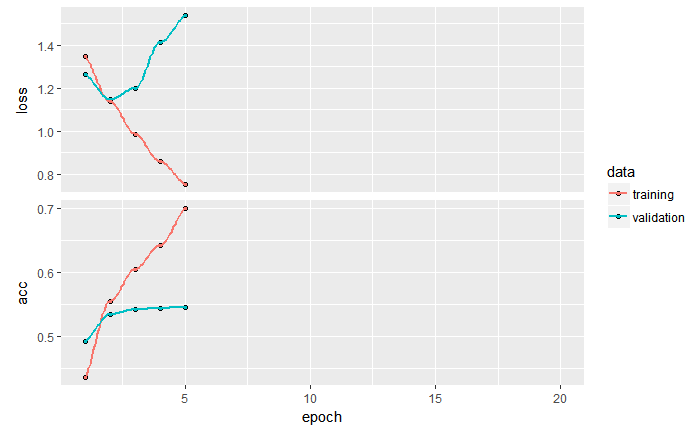

```r
# build train and test set
train_cnn = list()
test_cnn = list()
train.index.cnn = train.index.main # use same training index as for the first CNN model
train_cnn$x = sequences[train.index.cnn]
test_cnn$x =  sequences[-train.index.cnn]
train_cnn$y = predicter_presidents_id_cnn[train.index.cnn]
test_cnn$y =  predicter_presidents_id_cnn[-train.index.cnn]
# padd shorter sequences with zeros
x_train_cnn = train_cnn$x %>% pad_sequences(maxlen = maxlen)
x_test_cnn = test_cnn$x %>% pad_sequences(maxlen = maxlen)
# one hot encoding
y_train_cnn = to_categorical(train_cnn$y)
y_test_cnn = to_categorical(test_cnn$y)
# initiate model
model5 = keras_model_sequential()
# define model layers
model5 %>%
  # embedding layer maps vocab indices into embedding_dims dimensions
  layer_embedding(max_features, embedding_dims, input_length = maxlen) %>%

  # add some dropout
  layer_dropout(0.2) %>%

  # 1st convolutional layer
  layer_conv_1d(
    filters = 500,
    kernel_size = 2,
    padding = 'valid',  # "valid" means no padding, as we did it already
    activation = 'relu',
    strides = 1) %>%
  # 2nd convolutional layer
  layer_conv_1d(
    filters = 500,
    kernel_size = 3,
    padding = 'valid',  # "valid" means no padding, as we did it already
    activation = 'relu',
    strides = 1) %>%
  # 3rd convolutional layer
  layer_conv_1d(
    filters = 500,
    kernel_size = 4,
    padding = 'valid',  # "valid" means no padding, as we did it already
    activation = 'relu',
    strides = 1) %>%
  layer_global_max_pooling_1d() %>%

  layer_dense(units = 128,
              activation = 'relu') %>%
  layer_dropout(0.2) %>%
  layer_dense(units = output_shape) %>%
  layer_activation('softmax')
# compile model
model5 %>% compile(
  optimizer = 'adam',
  loss = 'categorical_crossentropy',
  metrics = c('accuracy')
)
# fit model
history5 = model5 %>%
  fit(x = x_train_cnn,
      y = y_train_cnn,
      epochs = 20,
      batch_size = 16,
      callbacks = list(callback_early_stopping(monitor = "val_loss", min_delta = 0.001, patience = 3)), # increase patience from 1 to 3
      verbose = 0,
      validation_data = list(x_test_cnn, y_test_cnn))
plot(history5)
```

Save model

```r
save_model_hdf5(model5, "models/Waldo_SONA_model5.h5") #save model to use later on
save_model_weights_hdf5(model5, "models/Waldo_SONA_model5_weights.h5") #save model weights to use later on
save(history5, file = "models/history5.RData")
```

Load model

```r
#model5 = load_model_hdf5("models/Waldo_SONA_model5.h5")
#load_model_weights_hdf5(model5, "models/Waldo_SONA_model5_weights.h5")
#load("models/history5.RData")
```

```r
cat("Train classification success rate = ", mean(model5$predict_classes(x_train_cnn) == train_cnn$y), "\n")
```

```
Train classification success rate =  0.7718554
```

```r
cat("Test classification success rate = ", mean(model5$predict_classes(x_test_cnn) == test_cnn$y))
```

```
Test classification success rate =  0.5457227
```

This model only achieved an accuracy of 54.6% which is not better than our first CNN model which achieved 59.2%. It seems that a more general approach worked better than to add to many extra layers.

## RNN

We can also look at a Recurrent Neural Network (RNN) which is similar to a CNN, where the output depends not only on the present inputs but also on the previous step’s neuron state. The order of words is preserved by using long short-term memory. We can also use Keras to build a RNN and use the Long Short-Term Memory (LSTM) layer.

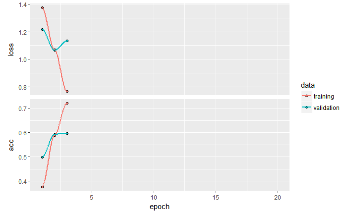

```r
# initiate model
model6 = keras_model_sequential()
# define model layers
model6 %>%
  # embedding layer maps vocab indices into embedding_dims dimensions
  layer_embedding(max_features, embedding_dims, input_length = maxlen) %>%

  # add some dropout
  layer_dropout(0.2) %>%

  # add long short-term memory layer
  layer_lstm(128, input_shape = c(maxlen, ncol(x_train_cnn))) %>%
  layer_dense(units = 128,
              activation = 'relu') %>%
  layer_dropout(0.2) %>%
  layer_dense(units = output_shape) %>%
  layer_activation('softmax')
# compile model
model6 %>% compile(
  optimizer = 'adam',
  loss = 'categorical_crossentropy',
  metrics = c('accuracy')
)
# fit model
history6 = model6 %>%
  fit(x = x_train_cnn,
      y = y_train_cnn,
      #class_weight = list("0"=26.8, "1"=1.5, "2"=1.0, "3"=9.6, "4"=1.0, "5"=10.7),
      epochs = 20,
      batch_size = 16,
      callbacks = list(callback_early_stopping(monitor = "val_loss", min_delta = 0.001, patience = 1)),
      verbose = 0,
      validation_data = list(x_test_cnn, y_test_cnn))
plot(history6)
```

Save model

```r
save_model_hdf5(model6, "models/Waldo_SONA_model6.h5") #save model to use later on
save_model_weights_hdf5(model6, "models/Waldo_SONA_model6_weights.h5") #save model weights to use later on
save(history6, file = "models/history6.RData")
```

Load model

```r
#model6 = load_model_hdf5("models/Waldo_SONA_model6.h5")
#load_model_weights_hdf5(model6, "models/Waldo_SONA_model6_weights.h5")
#load("models/history6.RData")
```

```r
cat("Train classification success rate = ", mean(model6$predict_classes(x_train_cnn) == train_cnn$y), "\n")
```

```
Train classification success rate =  0.8227591
```

```r
cat("Test classification success rate = ", mean(model6$predict_classes(x_test_cnn) == test_cnn$y))
```

```
Test classification success rate =  0.5973451
```

The RNN is fairly simple model and have our best accuracy when compared to our previous models (59.7% compared to 59.2%).

## Make some predictions

Let’s look at some test predictions by selecting 5 random sentences from our validation data set.

```r
set.seed(123)
# select 5 random test sentences
test_index = (1:length(sequences))[-train.index.main] # retrieve the validation indexes as positions in the sequences data set
test_samples = sample(test_index, , size = 5, replace = F) # select 5 random test sentences
j = 0
for (i in test_samples)
{
  j = j +1
  cat("TEST", j, "\n")
  cat("======", "\n\n")
  cat("Original sentence:\n", sona_sentences[i,]$sentence, sep = "", "\n\n")
  cat("Core sentence:\n", sona_sentences[i,]$core_sentence, sep = "", "\n\n")
  cat("Actual president:", sona_sentences[i,]$president, "\n")
  cat("Predicted president:", c("deKlerk", "Mandela", "Mbeki", "Motlanthe", "Zuma", "Ramaphosa")[ match(model6$predict_classes(matrix(x_test_cnn[which(test_index == i),], nrow = 1, ncol = 50)), (0:5))], "\n\n")
}
```

```
TEST 1
======

Original sentence:
as much as the rest of the world stood with us as we fought to end the system of apartheid, which struggle brought about the announcements that were made from this rostrum as the apartheid parliament opened 10 years ago, so do we have an obligation ourselves to contribute to the construction of a be…

Core sentence:
rest world stood fought system apartheid struggle brought announcements rostrum apartheid parliament ago obligation contribute construction world humanity

Actual president: Mbeki
Predicted president: Zuma

TEST 2
======

Original sentence:
compatriots,  next year 2013, the seat of government, the majestic union buildings, will mark 100 years of existence and planning will start this year to mark the centenary.

Core sentence:
compatriots seat government majestic union buildings mark existence planning start mark centenary

Actual president: Zuma
Predicted president: Zuma

TEST 3
======

Original sentence:
murder has been reduced by almost 17%.

Core sentence:
murder reduced

Actual president: Mbeki
Predicted president: Mbeki

TEST 4
======

Original sentence:
i will report back on the five priorities, starting with the economy.

Core sentence:
report priorities starting economy

Actual president: Zuma
Predicted president: Zuma

TEST 5
======

Original sentence:
as a priority we are going to stabilise eskomâ€™s finances to enable the utility to manage the current period.

Core sentence:
priority stabilise eskomâ finances enable utility manage current period

Actual president: Zuma
Predicted president: Zuma
```

We can observe the confusion matrix for this RNN model from which we can see that the model gets confused in the following ways:

- Predict Mandela correctly most of the time (43.6%), but confuse him with Mbeki 38% of the time.
- Mostly thinks Motlanthe is Mbeki (42.3% of the time), while only predicting Motlanthe correctly 3.8% of the time.
- Fail to predict Ramaphoza and thinks he is Zuma 46.7% of the time.

```r
pres_actual_rnn = c("deKlerk", "Mandela", "Mbeki", "Motlanthe", "Zuma", "Ramaphosa")[ match(test_cnn$y, (0:5))]
pres_predicted_rnn = c("deKlerk", "Mandela", "Mbeki", "Motlanthe", "Zuma", "Ramaphosa")[ match(model6$predict_classes(x_test_cnn), (0:5))]
kable(table(predicted = pres_predicted_rnn, actual = pres_actual_rnn),
      caption = "Training confusion matrix for RNN",
      row.names = TRUE, digits = 0)
```

|  | deKlerk | Mandela | Mbeki | Motlanthe | Ramaphosa | Zuma |
| --- | --- | --- | --- | --- | --- | --- |
| deKlerk | 10 | 4 | 3 | 1 | 0 | 1 |
| Mandela | 3 | 133 | 94 | 13 | 7 | 43 |
| Mbeki | 1 | 116 | 281 | 22 | 14 | 56 |
| Motlanthe | 1 | 2 | 1 | 2 | 3 | 0 |
| Ramaphosa | 0 | 0 | 0 | 0 | 0 | 1 |
| Zuma | 2 | 50 | 73 | 14 | 21 | 384 |

We can also compare the baseline accuracy with the validation prediction accuracy.

```r
model6_summary = data.frame(matrix(NA, nrow = 6, ncol = 0))
model6_summary$Total.Sentences = table(sona_sentences$president)
model6_summary$Baseline.Accuracy = table(sona_sentences$president) / nrow(sona_sentences)
model6_summary$Prediction.Accuracy = diag(table(predicted = pres_predicted_rnn, actual = pres_actual_rnn)) / table(pres_actual_rnn)
rownames(model6_summary) = rownames(table(sona_sentences$president))
model6_summary$Baseline.Accuracy = round(model6_summary$Baseline.Accuracy, 4) * 100
model6_summary$Prediction.Accuracy = round(model6_summary$Prediction.Accuracy, 4) * 100
kable(model6_summary,
      caption = "RNN model summary",
      row.names = TRUE, digits = 0)
```

|  | Total.Sentences | Baseline.Accuracy | Prediction.Accuracy |
| --- | --- | --- | --- |
| deKlerk | 97 | 1.33 | 58.82 |
| Mandela | 1661 | 22.72 | 43.61 |
| Mbeki | 2400 | 32.83 | 62.17 |
| Motlanthe | 264 | 3.61 | 3.85 |
| Ramaphosa | 237 | 3.24 | 0.00 |
| Zuma | 2651 | 36.27 | 79.18 |

## Conclusion

The aim for this dataset was to extract interesting features in the text. This was obtained by tokenising on words, using bag of words, TF-IDF frequencies and text wrangling like removing stop words and looking at stem words. As expected, many of the words used in SONAs are repeated, but despite this, the topics found for each president (or combination thereof) did differ slightly and we could even see ‘handover’ from one president to another in some cases (e.g. Mandela and Mbeki used topic 3.) Sentiment analysis also showed us, interestingly, that the last speech of each president was below the average sentiment score. Using negation also increased the accuracy of the sentiment analysis score, where we could see that for example de Klerk’s speech scored higher (more positive) when using negation than without it.

To predict which president said a sentence, the training data was split into a train and test set. Taking a random guess for our dataset of six presidents, given a sentence, one has a chance of 16.67% (1 out of 6) to correctly guess the president who used the sentence in his SONA. A smarter guess would be to look at the distribution of sentences, then guessing always Zuma, would give an accuracy of 36.3%. So the aim with our neural networks was to beat these chances. The following neural network models were built to predict the president from any given sentence extracted from a SONA speech:

- Feed-forward neural network (general) with an accuracy of 49.2%
- Feed-forward neural network (with tf-idf) with an accuracy of 22%
- Convolutional Neural Network (with embeddings) with an accuracy of 59.2%
- Recurrent Neural Network with an accuracy of 59.7%

The feed-forward neural networks did not perform very as well they do not preserve the order of words within sentences. Therefore, the convolutional and recurrent neural networks performed much better where the order of words are preserved. Correction of class imbalances were also attempted but this did not provide any significant improvement, and therefore a decision was made to keep class data as provided.

Our final choice for a model to predict a president is the recurrent neural network as it is fairly simple and had the best performance.

## Group contributions

The group had 3 members, collaborating on a shared repository on github (see https://github.com/WaldoLeonhardt/DS-for-Industry for details.) Waldo’s file was used as a base, then Marike and Francois added contributions with pull and push requests.

| Name | Contribution |
| --- | --- |
| All | Data wrangling, basic Feed-forward neural net, review of report |
| Marike du Plessis | Sentiment analysis, Topic analysis and Worcloud |
| Waldo Leonhardt | Feed-forward neural net, CNN and RNN with hyperparameter tuning |
| Francois Evert | Bag of words, Bigrams with negation, TF-IDF for feed-forward neural net |

Table showing group contributions